# Urban Delivery Demand Prediction using T-GCN

### Authored by

Lia Annie John

### Duration

90 minutes

### Level

Intermediate

### Pre-requisite Skills

- Python
- Data Analysis
- Data Visualisation
- Deep Learning
- Graph Neural Networks
- PyTorch

## Project Overview

This project focuses on predicting last-mile delivery demand across different zones in a city. Accurate demand prediction helps optimise delivery planning, reduce delays, and improve overall operational efficiency.

## Objective

The main objective is to compare different modelling approaches, including:

- LSTM (temporal baseline)
- T-GCN (spatio-temporal model)

and evaluate how spatial relationships between zones influence prediction performance.

## Approach

The project follows a structured workflow:

- Data preprocessing and transformation into time-series format
- Creation of delivery zones and demand aggregation
- Construction of graph-based representations between zones
- Implementation of LSTM and T-GCN models
- Evaluation using MAE and RMSE

## Reproducibility

To ensure consistent results across runs, a fixed random seed is used for NumPy, Python, and PyTorch, along with deterministic settings for model training.

## Data Loading and Initial Exploration

The dataset is loaded and basic structure, columns, and data types are examined to understand the data before preprocessing.

```python
# Reproducibility setup

SEED = 224805756

import random
import numpy as np
import torch

random.seed(SEED)
np.random.seed(SEED)
torch.manual_seed(SEED)

if torch.cuda.is_available():
    torch.cuda.manual_seed_all(SEED)

print("Seed set to:", SEED)
```

```
Seed set to: 224805756
```

```python
# Imports
import pandas as pd
import numpy as np
import matplotlib.pyplot as plt
import seaborn as sns

# Load dataset
df = pd.read_csv("talabat_enhanced_orders.csv")

# Basic inspection
print("Shape:", df.shape)
print("\nColumns:\n", df.columns)

df.head()
df.info()
```

```
Shape: (100000, 23)

Columns:
 Index(['Order_ID', 'User_ID', 'Restaurant_ID', 'Driver_ID', 'Item_Name',
       'Quantity', 'Total_Price', 'Order_Time', 'Delivery_Time',
       'Delivery_Duration_Minutes', 'City', 'Payment_Method', 'Order_Status',
       'Driver_Vehicle', 'Restaurant_Lat', 'Restaurant_Lon', 'Customer_Lat',
       'Customer_Lon', 'Driver_Lat', 'Driver_Lon', 'Delivery_Distance_km',
       'Traffic_Level', 'Driver_Availability'],
      dtype='object')
<class 'pandas.core.frame.DataFrame'>
RangeIndex: 100000 entries, 0 to 99999
Data columns (total 23 columns):
 #   Column                     Non-Null Count   Dtype
---  ------                     --------------   -----
 0   Order_ID                   100000 non-null  int64
 1   User_ID                    100000 non-null  object
 2   Restaurant_ID              100000 non-null  int64
 3   Driver_ID                  100000 non-null  int64
 4   Item_Name                  100000 non-null  object
 5   Quantity                   100000 non-null  int64
 6   Total_Price                100000 non-null  float64
 7   Order_Time                 100000 non-null  object
 8   Delivery_Time              100000 non-null  object
 9   Delivery_Duration_Minutes  100000 non-null  int64
 10  City                       100000 non-null  object
 11  Payment_Method             100000 non-null  object
 12  Order_Status               100000 non-null  object
 13  Driver_Vehicle             100000 non-null  object
 14  Restaurant_Lat             100000 non-null  float64
 15  Restaurant_Lon             100000 non-null  float64
 16  Customer_Lat               100000 non-null  float64
 17  Customer_Lon               100000 non-null  float64
 18  Driver_Lat                 100000 non-null  float64
 19  Driver_Lon                 100000 non-null  float64
 20  Delivery_Distance_km       100000 non-null  float64
 21  Traffic_Level              100000 non-null  object
 22  Driver_Availability        100000 non-null  object
dtypes: float64(8), int64(5), object(10)
memory usage: 17.5+ MB
```

## Data Cleaning and Preprocessing

Initial data cleaning steps are performed to ensure data quality, including checking for missing values, duplicate records, and converting date-time columns into proper formats for time-based analysis.

```python
# Check for missing values
missing_values = df.isnull().sum()
print("Missing Values:\n", missing_values)

# Check for duplicate records
duplicate_count = df.duplicated().sum()
print("\nDuplicate Rows:", duplicate_count)

# Convert date-time columns
df['Order_Time'] = pd.to_datetime(df['Order_Time'])
df['Delivery_Time'] = pd.to_datetime(df['Delivery_Time'])

# Preview converted columns
df[['Order_Time', 'Delivery_Time']].head()
```

```
Missing Values:
 Order_ID                     0
User_ID                      0
Restaurant_ID                0
Driver_ID                    0
Item_Name                    0
Quantity                     0
Total_Price                  0
Order_Time                   0
Delivery_Time                0
Delivery_Duration_Minutes    0
City                         0
Payment_Method               0
Order_Status                 0
Driver_Vehicle               0
Restaurant_Lat               0
Restaurant_Lon               0
Customer_Lat                 0
Customer_Lon                 0
Driver_Lat                   0
Driver_Lon                   0
Delivery_Distance_km         0
Traffic_Level                0
Driver_Availability          0
dtype: int64

Duplicate Rows: 0
```

|  | Order_Time | Delivery_Time |
| --- | --- | --- |
| 0 | 2025-06-16 08:32:00 | 2025-06-16 09:11:00 |
| 1 | 2025-06-03 21:27:00 | 2025-06-03 22:00:00 |
| 2 | 2025-06-01 14:48:00 | 2025-06-01 15:26:00 |
| 3 | 2025-06-13 02:30:00 | 2025-06-13 03:22:00 |
| 4 | 2025-06-06 09:48:00 | 2025-06-06 10:32:00 |

### Observations

- No missing values were found in the dataset.
- No duplicate records were detected.
- Date-time columns were successfully converted for further time-series analysis.

## Feature Engineering and Exploratory Analysis

New time-based features are created from the order timestamp, and delivery duration is calculated. Basic exploratory analysis is also performed on categorical and location-based variables to understand data distribution.

```python
# Create time-based features
df['order_hour'] = df['Order_Time'].dt.hour
df['order_day'] = df['Order_Time'].dt.day
df['order_month'] = df['Order_Time'].dt.month
df['order_weekday'] = df['Order_Time'].dt.weekday
df['is_weekend'] = df['order_weekday'].isin([5, 6]).astype(int)

# Create delivery duration
df['delivery_duration_mins'] = (
    (df['Delivery_Time'] - df['Order_Time']).dt.total_seconds() / 60
)

print("Delivery Duration Summary:\n")
print(df['delivery_duration_mins'].describe())
```

```
Delivery Duration Summary:

count    100000.000000
mean         37.520110
std          10.060876
min          15.000000
25%          30.000000
50%          38.000000
75%          45.000000
max          60.000000
Name: delivery_duration_mins, dtype: float64
```

```python
# Explore categorical variables
categorical_cols = ['Payment_Method', 'Traffic_Level', 'Order_Status', 'Driver_Vehicle']

for col in categorical_cols:
    if col in df.columns:
        print(f"\n{col} Distribution:\n")
        print(df[col].value_counts())
```

```
Payment_Method Distribution:

Payment_Method
Cash           33528
Wallet         33250
Credit Card    33222
Name: count, dtype: int64

Traffic_Level Distribution:

Traffic_Level
Low       45826
High      29220
Medium    24954
Name: count, dtype: int64

Order_Status Distribution:

Order_Status
Delivered     85197
Cancelled      9812
In Transit     4991
Name: count, dtype: int64

Driver_Vehicle Distribution:

Driver_Vehicle
Bicycle      33393
Car          33362
Motorbike    33245
Name: count, dtype: int64
```

```python
# Location statistics
location_cols = ['Restaurant_Lat', 'Restaurant_Lon', 'Customer_Lat', 'Customer_Lon']

print("\nLocation Summary:\n")
print(df[location_cols].describe())
```

```
Location Summary:

       Restaurant_Lat  Restaurant_Lon   Customer_Lat   Customer_Lon
count   100000.000000   100000.000000  100000.000000  100000.000000
mean        30.119015       31.063065      30.119060      31.062971
std          1.271638        0.487754       1.271674       0.487811
min         27.160900       29.898701      27.160900      29.898706
25%         30.023110       31.008774      30.023370      31.008460
50%         30.587306       31.209099      30.587054      31.208817
75%         31.026912       31.371676      31.027112      31.371856
max         31.220099       31.521997      31.220096      31.521995
```

### Observations

- Delivery duration shows a reasonable range, with most deliveries completed within a consistent time window.
- Categorical variables such as traffic level and order status are well distributed, indicating variability in delivery conditions.
- Location data appears consistent and suitable for spatial clustering and zone creation.

## Demand Aggregation, Zone Creation, and Graph Construction

Completed orders are filtered and aggregated into hourly zone-level demand. Restaurant coordinates are clustered into delivery zones using KMeans, and an adjacency matrix is created based on zone distances to support graph-based modelling.

```python
# Remove unrealistic delivery durations
df = df[df['delivery_duration_mins'] >= 0].copy()

# Keep only completed / delivered orders
df = df[df['Order_Status'] == 'Delivered'].copy()

# Create hourly time buckets
df['date_hour'] = df['Order_Time'].dt.floor('h')

print("Filtered data shape:", df.shape)
```

```
Filtered data shape: (85197, 30)
```

```python
# Create delivery zones using restaurant coordinates
from sklearn.cluster import KMeans

coords = df[['Restaurant_Lat', 'Restaurant_Lon']]

kmeans = KMeans(
    n_clusters=10,
    random_state=SEED,
    n_init=10
)

df['zone'] = kmeans.fit_predict(coords)

print("Zone counts:")
print(df['zone'].value_counts().sort_index())
```

```
Zone counts:
zone
0    12220
1     6182
2     7280
3    12110
4     5540
5    11946
6    10286
7     6910
8     6773
9     5950
Name: count, dtype: int64
```

```python
# Create hourly demand variable
zone_demand = (
    df.groupby(['zone', 'date_hour'])
      .size()
      .reset_index(name='demand')
)

zone_demand.head()
```

|  | zone | date_hour | demand |
| --- | --- | --- | --- |
| 0 | 0 | 2025-06-01 10:00:00 | 39 |
| 1 | 0 | 2025-06-01 11:00:00 | 31 |
| 2 | 0 | 2025-06-01 12:00:00 | 29 |
| 3 | 0 | 2025-06-01 13:00:00 | 26 |
| 4 | 0 | 2025-06-01 14:00:00 | 30 |

```python
# Encode traffic level
from sklearn.preprocessing import LabelEncoder

le = LabelEncoder()
df['Traffic_Level_Encoded'] = le.fit_transform(df['Traffic_Level'])

# Aggregate additional features
features_df = (
    df.groupby(['zone', 'date_hour'])
      .agg({
          'Quantity': 'sum',
          'Total_Price': 'sum',
          'delivery_duration_mins': 'mean',
          'Traffic_Level_Encoded': 'mean'
      })
      .reset_index()
)

# Merge demand and additional features
model_df = pd.merge(
    zone_demand,
    features_df,
    on=['zone', 'date_hour'],
    how='left'
).fillna(0)

model_df.head()
```

|  | zone | date_hour | demand | Quantity | Total_Price | delivery_duration_mins | Traffic_Level_Encoded |
| --- | --- | --- | --- | --- | --- | --- | --- |
| 0 | 0 | 2025-06-01 10:00:00 | 39 | 127 | 11341.65 | 37.974359 | 2.0 |
| 1 | 0 | 2025-06-01 11:00:00 | 31 | 88 | 8052.46 | 38.548387 | 2.0 |
| 2 | 0 | 2025-06-01 12:00:00 | 29 | 85 | 7406.13 | 39.275862 | 2.0 |
| 3 | 0 | 2025-06-01 13:00:00 | 26 | 80 | 6702.07 | 39.307692 | 2.0 |
| 4 | 0 | 2025-06-01 14:00:00 | 30 | 107 | 9589.63 | 38.566667 | 2.0 |

```python
# Pivot demand data into time-series format
pivot_demand = (
    model_df.pivot(
        index='date_hour',
        columns='zone',
        values='demand'
    )
    .fillna(0)
    .sort_index()
)

print("Pivot demand shape:", pivot_demand.shape)
pivot_demand.head()
```

```
Pivot demand shape: (361, 10)
```

| zone date_hour | 0 | 1 | 2 | 3 | 4 | 5 | 6 | 7 | 8 | 9 |
| --- | --- | --- | --- | --- | --- | --- | --- | --- | --- | --- |
| 2025-06-01 10:00:00 | 39.0 | 18.0 | 20.0 | 31.0 | 11.0 | 32.0 | 31.0 | 24.0 | 20.0 | 15.0 |
| 2025-06-01 11:00:00 | 31.0 | 22.0 | 24.0 | 27.0 | 18.0 | 25.0 | 29.0 | 27.0 | 22.0 | 20.0 |
| 2025-06-01 12:00:00 | 29.0 | 19.0 | 18.0 | 37.0 | 10.0 | 34.0 | 37.0 | 20.0 | 20.0 | 14.0 |
| 2025-06-01 13:00:00 | 26.0 | 15.0 | 24.0 | 24.0 | 16.0 | 29.0 | 24.0 | 22.0 | 19.0 | 5.0 |
| 2025-06-01 14:00:00 | 30.0 | 25.0 | 21.0 | 25.0 | 21.0 | 39.0 | 34.0 | 14.0 | 18.0 | 15.0 |

```python
# Create time-series sequences
def create_sequences(data, seq_length=6):
    X, y = [], []

    for i in range(len(data) - seq_length):
        X.append(data[i:i + seq_length])
        y.append(data[i + seq_length])

    return np.array(X), np.array(y)


seq_length = 6
data = pivot_demand.values

X, y = create_sequences(data, seq_length=seq_length)

print("X shape:", X.shape)
print("y shape:", y.shape)
```

```
X shape: (355, 6, 10)
y shape: (355, 10)
```

# Create distance-based adjacency matrix for T-GCN

```python
# Create distance-based adjacency matrix for T-GCN
from sklearn.metrics.pairwise import euclidean_distances

zone_coords = (
    df.groupby('zone')[['Restaurant_Lat', 'Restaurant_Lon']]
      .mean()
      .sort_index()
)

dist_matrix = euclidean_distances(zone_coords)

adj_matrix = np.exp(-dist_matrix)

print("Adjacency matrix shape:", adj_matrix.shape)
```

```
Adjacency matrix shape: (10, 10)
```

### Graph Construction

A distance-based adjacency matrix is created using restaurant coordinates. This matrix represents spatial relationships between zones and is used as input for the T-GCN model.

```python
# Save processed outputs
df.to_csv("cleaned_orders.csv", index=False)
model_df.to_csv("zone_time_features.csv", index=False)
pivot_demand.to_csv("pivot_demand.csv")

print("Processed files saved successfully.")
```

```
Processed files saved successfully.
```

### Observations

- Demand was successfully aggregated into hourly zone-level time series.
- The pivoted dataset shows consistent demand patterns across all 10 zones.
- Sequence creation resulted in input shape (samples, time steps, zones), which is suitable for both LSTM and T-GCN models.
- The adjacency matrix captures spatial relationships between zones based on distance.

## LSTM Baseline Model

The LSTM model is used as a temporal baseline to predict future delivery demand from previous hourly demand sequences. The data is split chronologically to avoid data leakage, then scaled before training.

```python
# Chronological train-test split
split_idx = int(len(X) * 0.8)

X_train, X_test = X[:split_idx], X[split_idx:]
y_train, y_test = y[:split_idx], y[split_idx:]

print("X_train:", X_train.shape)
print("X_test:", X_test.shape)
print("y_train:", y_train.shape)
print("y_test:", y_test.shape)
```

```
X_train: (284, 6, 10)
X_test: (71, 6, 10)
y_train: (284, 10)
y_test: (71, 10)
```

```python
from sklearn.preprocessing import MinMaxScaler

scaler_X = MinMaxScaler()
scaler_y = MinMaxScaler()

X_train_2d = X_train.reshape(-1, X_train.shape[-1])
X_test_2d = X_test.reshape(-1, X_test.shape[-1])

X_train_scaled = scaler_X.fit_transform(X_train_2d).reshape(X_train.shape)
X_test_scaled = scaler_X.transform(X_test_2d).reshape(X_test.shape)

y_train_scaled = scaler_y.fit_transform(y_train)
y_test_scaled = scaler_y.transform(y_test)
```

```python
# Build LSTM baseline model
import tensorflow as tf
from tensorflow.keras.models import Sequential
from tensorflow.keras.layers import Input, LSTM, Dense, Dropout
from tensorflow.keras.callbacks import EarlyStopping
from sklearn.metrics import r2_score

tf.random.set_seed(SEED)

model = Sequential([
    Input(shape=(X_train_scaled.shape[1], X_train_scaled.shape[2])),
    LSTM(64, activation='tanh'),
    Dropout(0.2),
    Dense(32, activation='relu'),
    Dense(y_train_scaled.shape[1])
])

model.compile(
    optimizer='adam',
    loss='mse',
    metrics=['mae']
)

model.summary()
```

```
WARNING:tensorflow:TensorFlow GPU support is not available on native Windows for TensorFlow >= 2.11. Even if CUDA/cuDNN are installed, GPU will not be used. Please use WSL2 or the TensorFlow-DirectML plugin.
```

```
Model: "sequential"
```

```
┏━━━━━━━━━━━━━━━━━━━━━━━━━━━━━━━━━━━━━━┳━━━━━━━━━━━━━━━━━━━━━━━━━━━━━┳━━━━━━━━━━━━━━━━━┓
┃ Layer (type)                         ┃ Output Shape                ┃         Param # ┃
┡━━━━━━━━━━━━━━━━━━━━━━━━━━━━━━━━━━━━━━╇━━━━━━━━━━━━━━━━━━━━━━━━━━━━━╇━━━━━━━━━━━━━━━━━┩
│ lstm (LSTM)                          │ (None, 64)                  │          19,200 │
├──────────────────────────────────────┼─────────────────────────────┼─────────────────┤
│ dropout (Dropout)                    │ (None, 64)                  │               0 │
├──────────────────────────────────────┼─────────────────────────────┼─────────────────┤
│ dense (Dense)                        │ (None, 32)                  │           2,080 │
├──────────────────────────────────────┼─────────────────────────────┼─────────────────┤
│ dense_1 (Dense)                      │ (None, 10)                  │             330 │
└──────────────────────────────────────┴─────────────────────────────┴─────────────────┘
```

```
 Total params: 21,610 (84.41 KB)
```

```
 Trainable params: 21,610 (84.41 KB)
```

```
 Non-trainable params: 0 (0.00 B)
```

```python
# Train LSTM model
early_stop = EarlyStopping(
    monitor='val_loss',
    patience=10,
    restore_best_weights=True
)

history = model.fit(
    X_train_scaled,
    y_train_scaled,
    validation_split=0.2,
    epochs=100,
    batch_size=16,
    callbacks=[early_stop],
    verbose=0
)

print("LSTM training completed.")
```

```
LSTM training completed.
```

### LSTM Training Observation

The LSTM baseline was trained using early stopping to reduce overfitting. This model captures temporal demand patterns but does not explicitly model spatial relationships between delivery zones.

```python
# Evaluate LSTM on test set
y_pred_scaled = model.predict(X_test_scaled)

# inverse transform
y_pred = scaler_y.inverse_transform(y_pred_scaled)
y_true = scaler_y.inverse_transform(y_test_scaled)

from sklearn.metrics import mean_absolute_error, mean_squared_error

mae = mean_absolute_error(y_true, y_pred)
rmse = np.sqrt(mean_squared_error(y_true, y_pred))

print("LSTM Test MAE:", mae)
print("LSTM Test RMSE:", rmse)
```

```
3/3 ━━━━━━━━━━━━━━━━━━━━ 1s 148ms/step
LSTM Test MAE: 4.173623509474203
LSTM Test RMSE: 5.582506338659327
```

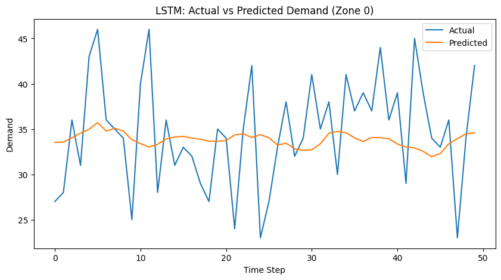

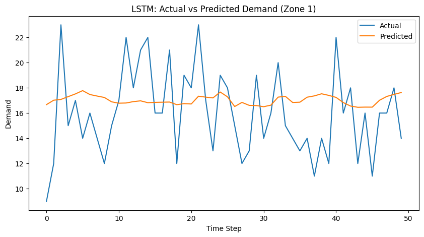

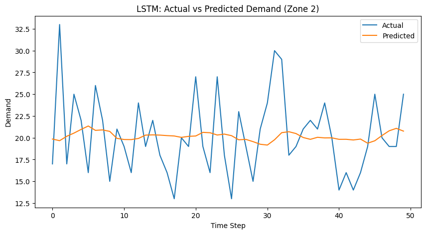

```python
# Plot sample zones
for zone_idx in [0, 1, 2]:
    plt.figure(figsize=(10, 5))
    plt.plot(y_true[:50, zone_idx], label='Actual')
    plt.plot(y_pred[:50, zone_idx], label='Predicted')
    plt.title(f"LSTM: Actual vs Predicted Demand (Zone {zone_idx})")
    plt.xlabel("Time Step")
    plt.ylabel("Demand")
    plt.legend()
    plt.show()
```

```python
zone_results = []

for i in range(y_true.shape[1]):

    zone_mae = mean_absolute_error(y_true[:, i], y_pred[:, i])

    zone_rmse = np.sqrt(
        mean_squared_error(y_true[:, i], y_pred[:, i])
    )

    zone_r2 = r2_score(
        y_true[:, i],
        y_pred[:, i]
    )

    zone_results.append([
        i,
        zone_mae,
        zone_rmse,
        zone_r2
    ])

zone_results_df = pd.DataFrame(
    zone_results,
    columns=['zone', 'MAE', 'RMSE', 'R2']
)

zone_results_df
```

|  | zone | MAE | RMSE | R2 |
| --- | --- | --- | --- | --- |
| 0 | 0 | 5.458170 | 7.185418 | -0.007518 |
| 1 | 1 | 3.398399 | 4.315792 | -0.038214 |
| 2 | 2 | 3.992770 | 5.205944 | -0.008954 |
| 3 | 3 | 4.781616 | 6.655177 | -0.002798 |
| 4 | 4 | 3.835003 | 4.972322 | -0.040764 |
| 5 | 5 | 4.788165 | 6.286310 | 0.009494 |
| 6 | 6 | 4.585633 | 6.272160 | -0.036139 |
| 7 | 7 | 4.102980 | 5.168723 | -0.019468 |
| 8 | 8 | 3.403512 | 4.660353 | 0.004610 |
| 9 | 9 | 3.389987 | 4.240045 | 0.027691 |

### LSTM Results and Interpretation

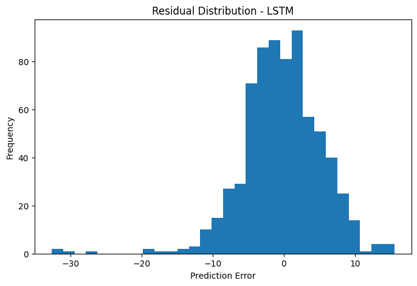

```python
residuals = y_true - y_pred
plt.figure(figsize=(8,5))
plt.hist(residuals.flatten(), bins=30)
plt.title("Residual Distribution - LSTM")
plt.xlabel("Prediction Error")
plt.ylabel("Frequency")
plt.show()
```

### Residual Analysis

The residual distribution is centred around zero, indicating that the model predictions are generally unbiased. However, the spread of residuals suggests that larger errors occur during periods of high demand variability.

This further confirms that while the LSTM captures overall trends, it struggles with sudden spikes and drops in demand, leading to higher prediction errors in such cases.

```python
# Save LSTM results
zone_results_df.to_csv("lstm_zonewise_results.csv", index=False)

lstm_overall_results = pd.DataFrame({
    'Metric': ['MAE', 'RMSE'],
    'Value': [mae, rmse]
})
lstm_overall_results.to_csv("lstm_overall_results.csv", index=False)
```

## T-GCN Model (Spatio-Temporal Learning)

The Temporal Graph Convolutional Network (T-GCN) extends traditional sequence models by incorporating spatial relationships between delivery zones using a graph structure. This allows the model to learn both temporal demand patterns and spatial dependencies across zones.

```python
# Convert data to PyTorch tensors (TRAIN ONLY)
import torch

device = torch.device("cuda" if torch.cuda.is_available() else "cpu")

X_train_tensor = torch.tensor(X_train_scaled, dtype=torch.float32).to(device)
y_train_tensor = torch.tensor(y_train_scaled, dtype=torch.float32).to(device)

X_test_tensor = torch.tensor(X_test_scaled, dtype=torch.float32).to(device)
```

```python
# Convert adjacency matrix to edge index format
adj_tensor = torch.tensor(adj_matrix, dtype=torch.float32)

edge_index = adj_tensor.nonzero().t().contiguous().to(device)

print("Edge index shape:", edge_index.shape)
```

```
Edge index shape: torch.Size([2, 100])
```

### Model Architecture

The model applies Graph Convolution (GCN) at each time step to capture spatial relationships, followed by a GRU layer to learn temporal dependencies.

```python
import torch.nn as nn
from torch_geometric.nn import GCNConv

class TGCN(nn.Module):
    def __init__(self, num_nodes, in_feats=1, hidden_dim=32):
        super(TGCN, self).__init__()

        self.num_nodes = num_nodes

        self.gcn = GCNConv(in_feats, hidden_dim)
        self.relu = nn.ReLU()
        self.gru = nn.GRU(hidden_dim * num_nodes, hidden_dim, batch_first=True)
        self.fc = nn.Linear(hidden_dim, num_nodes)

    def forward(self, X, edge_index):
        B, S, N = X.shape

        gcn_outputs = []

        for t in range(S):
            x_t = X[:, t, :].reshape(B * N, 1)

            edge_indices = []
            for b in range(B):
                edge_indices.append(edge_index + b * N)

            edge_batch = torch.cat(edge_indices, dim=1)

            out = self.gcn(x_t, edge_batch)
            out = self.relu(out)

            out = out.view(B, N * out.shape[1])
            gcn_outputs.append(out.unsqueeze(1))

        gcn_stack = torch.cat(gcn_outputs, dim=1)

        gru_out, _ = self.gru(gcn_stack)
        out = self.fc(gru_out[:, -1, :])

        return out
```

```python
torch.manual_seed(SEED)

num_nodes = X_train.shape[2]

model = TGCN(num_nodes=num_nodes).to(device)

optimizer = torch.optim.Adam(model.parameters(), lr=1e-3)
criterion = nn.MSELoss()
```

### Training

The model is trained using Mean Squared Error (MSE) loss and the Adam optimizer.

```python
epochs = 50

for epoch in range(epochs):
    model.train()

    optimizer.zero_grad()

    preds = model(X_train_tensor, edge_index)
    loss = criterion(preds, y_train_tensor)

    loss.backward()
    optimizer.step()

    if epoch % 10 == 0:
        print(f"Epoch {epoch}, Loss: {loss.item():.4f}")
```

```
Epoch 0, Loss: 0.2217
Epoch 10, Loss: 0.0945
Epoch 20, Loss: 0.0429
Epoch 30, Loss: 0.0339
Epoch 40, Loss: 0.0345
```

```python
# Overall metrics
mae = mean_absolute_error(y_true, y_pred)
rmse = np.sqrt(mean_squared_error(y_true, y_pred))
r2 = r2_score(y_true, y_pred)

print("T-GCN Test MAE:", mae)
print("T-GCN Test RMSE:", rmse)
print("T-GCN Test R²:", r2)
```

```
T-GCN Test MAE: 4.173623509474203
T-GCN Test RMSE: 5.582506338659327
T-GCN Test R²: -0.011206058677936458
```

```python
tgcn_zone_results = []

for i in range(y_true.shape[1]):

    zone_mae = mean_absolute_error(y_true[:, i], y_pred[:, i])

    zone_rmse = np.sqrt(
        mean_squared_error(y_true[:, i], y_pred[:, i])
    )

    zone_r2 = r2_score(
        y_true[:, i],
        y_pred[:, i]
    )

    tgcn_zone_results.append([
        i,
        zone_mae,
        zone_rmse,
        zone_r2
    ])

tgcn_zone_results_df = pd.DataFrame(
    tgcn_zone_results,
    columns=['zone', 'MAE', 'RMSE', 'R2']
)

tgcn_zone_results_df
```

|  | zone | MAE | RMSE | R2 |
| --- | --- | --- | --- | --- |
| 0 | 0 | 5.458170 | 7.185418 | -0.007518 |
| 1 | 1 | 3.398399 | 4.315792 | -0.038214 |
| 2 | 2 | 3.992770 | 5.205944 | -0.008954 |
| 3 | 3 | 4.781616 | 6.655177 | -0.002798 |
| 4 | 4 | 3.835003 | 4.972322 | -0.040764 |
| 5 | 5 | 4.788165 | 6.286310 | 0.009494 |
| 6 | 6 | 4.585633 | 6.272160 | -0.036139 |
| 7 | 7 | 4.102980 | 5.168723 | -0.019468 |
| 8 | 8 | 3.403512 | 4.660353 | 0.004610 |
| 9 | 9 | 3.389987 | 4.240045 | 0.027691 |

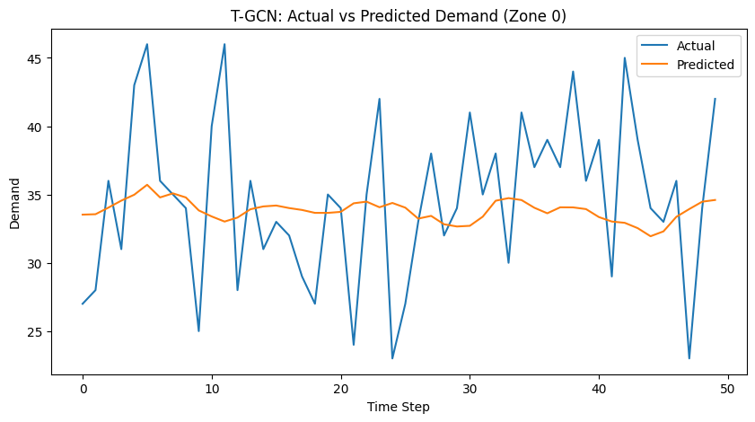

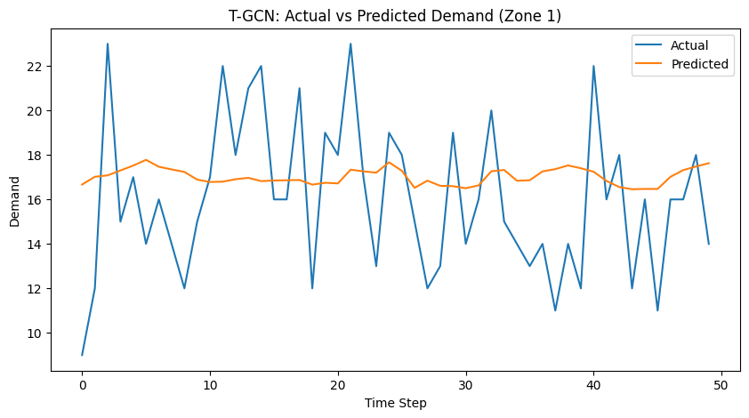

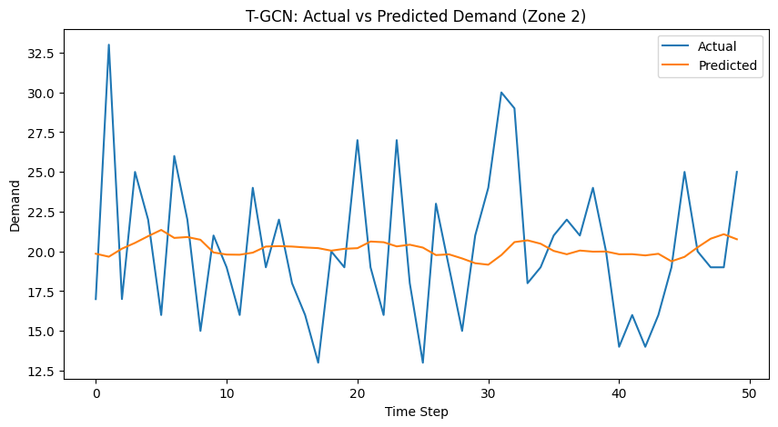

```python
# Plot sample zones
for zone_idx in [0, 1, 2]:
    plt.figure(figsize=(10, 5))
    plt.plot(y_true[:50, zone_idx], label='Actual')
    plt.plot(y_pred[:50, zone_idx], label='Predicted')
    plt.title(f"T-GCN: Actual vs Predicted Demand (Zone {zone_idx})")
    plt.xlabel("Time Step")
    plt.ylabel("Demand")
    plt.legend()
    plt.show()
```

### T-GCN Results and Interpretation

Additionally, the smooth nature of predictions indicates that while T-GCN captures general trends, it still struggles with sudden fluctuations in demand. This may be due to the simplicity of the graph structure used, which may not fully capture complex spatial interactions.

Overall, the results highlight that while graph-based models offer advantages, their effectiveness depends heavily on the quality of the constructed graph.

## Model Comparison

[output not shown]

## T-GCN Improvement Experiment: Sparse Top-K Graph

In this experiment, a sparse graph is constructed by connecting each zone to its top-k most similar neighbouring zones based on adjacency weights. The goal is to reduce noise in the graph and evaluate whether a more selective spatial structure improves T-GCN performance.

### Sparse Graph Construction

A top-k strategy is used to retain only the strongest connections for each node, creating a sparser and more meaningful graph structure.

```python
# Sparse Graph Construction
# Build a sparse graph using top-k strongest neighbours

X = np.array(X)              # shape: (N, seq_len, num_nodes)
y = np.array(y)              # shape: (N, num_nodes)
adj = np.array(adj_matrix)   # shape: (num_nodes, num_nodes)

num_samples, seq_len, num_nodes = X.shape

print("Data shapes:")
print("X:", X.shape)
print("y:", y.shape)
print("Adjacency matrix:", adj.shape)

# Top-k sparse graph construction
top_k = 4

rows = []
cols = []
vals = []

for i in range(num_nodes):

    # Sort neighbours by descending similarity
    neigh_idx = np.argsort(-adj[i, :])

    taken = 0

    for j in neigh_idx:

        # Skip self-connections
        if i == j:
            continue

        # Keep only top-k neighbours
        if taken >= top_k:
            break

        rows.append(i)
        cols.append(j)
        vals.append(adj[i, j])

        taken += 1

# Create graph tensors
edge_index = torch.tensor(
    [rows, cols],
    dtype=torch.long
).to(device)

edge_weight = torch.tensor(
    vals,
    dtype=torch.float32
).to(device)

print("Edge index shape:", edge_index.shape)
print("Edge weight shape:", edge_weight.shape)
```

```
Data shapes:
X: (355, 6, 10)
y: (355, 10)
Adjacency matrix: (10, 10)
Edge index shape: torch.Size([2, 40])
Edge weight shape: torch.Size([40])
```

### Data Splitting

The dataset is split chronologically into training, validation, and test sets to avoid data leakage.

```python
# Data Splitting
# Split dataset chronologically into train, validation, and test sets

split_idx = int(num_samples * 0.8)
val_idx = int(split_idx + (num_samples - split_idx) * 0.5)

# Training set
X_train = X[:split_idx]
y_train = y[:split_idx]

# Validation set
X_val = X[split_idx:val_idx]
y_val = y[split_idx:val_idx]

# Test set
X_test = X[val_idx:]
y_test = y[val_idx:]

print("Dataset splits:")
print("Train:", X_train.shape)
print("Validation:", X_val.shape)
print("Test:", X_test.shape)
```

```
Dataset splits:
Train: (284, 6, 10)
Validation: (35, 6, 10)
Test: (36, 6, 10)
```

```python
# Feature Scaling
# Scale target values using MinMaxScaler

from sklearn.preprocessing import MinMaxScaler

scaler_y = MinMaxScaler()

y_train_scaled = scaler_y.fit_transform(y_train)
y_val_scaled = scaler_y.transform(y_val)
y_test_scaled = scaler_y.transform(y_test)
```

### Dataset Preparation

Each sample is converted into a graph-compatible format with sequence input and target demand.

```python
# Dataset Preparation
# Convert each sample into a graph-compatible format

from torch_geometric.data import Data
from torch_geometric.loader import DataLoader

def make_dataset(X_arr, y_arr_scaled):

    dataset = []

    for i in range(X_arr.shape[0]):

        # Sequence input
        x_seq = torch.tensor(
            X_arr[i].reshape(seq_len, num_nodes, 1),
            dtype=torch.float32
        )

        # Target demand
        y_target = torch.tensor(
            y_arr_scaled[i],
            dtype=torch.float32
        )

        # Create graph data object
        data = Data()
        data.x_seq = x_seq
        data.y = y_target

        dataset.append(data)

    return dataset


train_dataset = make_dataset(X_train, y_train_scaled)
val_dataset = make_dataset(X_val, y_val_scaled)
test_dataset = make_dataset(X_test, y_test_scaled)

# Data loaders
train_loader = DataLoader(
    train_dataset,
    batch_size=16,
    shuffle=True
)

val_loader = DataLoader(
    val_dataset,
    batch_size=16,
    shuffle=False
)

test_loader = DataLoader(
    test_dataset,
    batch_size=16,
    shuffle=False
)
```

### T-GCN Model Architecture

The model combines Graph Convolution for spatial learning and GRU for temporal sequence modelling.

```python
# T-GCN Model Architecture
# Combines Graph Convolution and GRU layers

import torch.nn as nn
from torch_geometric.nn import GCNConv

class TGCN_Model(nn.Module):

    def __init__(
        self,
        num_nodes,
        seq_len,
        in_feats=1,
        gcn_out=16,
        gru_hidden=64
    ):

        super().__init__()

        self.num_nodes = num_nodes
        self.seq_len = seq_len

        # Graph convolution layer
        self.gcn = GCNConv(in_feats, gcn_out)

        # Activation
        self.relu = nn.ReLU()

        # Temporal learning layer
        self.gru = nn.GRU(
            gcn_out * num_nodes,
            gru_hidden,
            batch_first=True
        )

        # Output layer
        self.fc = nn.Linear(gru_hidden, num_nodes)

    def forward(self, batch_x_seq, edge_index, edge_weight=None):

        # Handle input dimensions
        if batch_x_seq.dim() == 3:

            total_steps, N, F = batch_x_seq.shape

            S = self.seq_len
            B = total_steps // S

            batch_x_seq = batch_x_seq.view(B, S, N, F)

        elif batch_x_seq.dim() == 4:

            B, S, N, F = batch_x_seq.shape

        else:
            raise ValueError(
                f"Unexpected input shape: {batch_x_seq.shape}"
            )

        gcn_outputs = []

        # Apply graph convolution for each time step
        for t in range(S):

            x_t = batch_x_seq[:, t, :, :].reshape(B * N, F)

            edge_indices = [
                edge_index + b * N
                for b in range(B)
            ]

            batched_edge_index = torch.cat(
                edge_indices,
                dim=1
            )

            if edge_weight is not None:
                batched_edge_weight = edge_weight.repeat(B)
            else:
                batched_edge_weight = None

            # Graph convolution
            out = self.gcn(
                x_t,
                batched_edge_index,
                batched_edge_weight
            )

            out = self.relu(out)

            # Reshape output
            out = out.view(B, N * out.shape[1])

            gcn_outputs.append(out.unsqueeze(1))

        # Stack temporal outputs
        gcn_stack = torch.cat(gcn_outputs, dim=1)

        # GRU temporal learning
        gru_out, _ = self.gru(gcn_stack)

        # Final prediction
        preds = self.fc(gru_out[:, -1, :])

        return preds
```

```python
# Model Initialisation

model = TGCN_Model(
    num_nodes=num_nodes,
    seq_len=seq_len
).to(device)

optimizer = torch.optim.Adam(
    model.parameters(),
    lr=1e-3
)

criterion = nn.MSELoss()

n_epochs = 60
best_val_loss = np.inf

patience = 8
wait = 0
```

### Training Observation

```python
# Train Sparse Top-K T-GCN model

train_history = []
val_history = []

for epoch in range(n_epochs):

    model.train()
    train_losses = []

    for batch in train_loader:
        batch_x = batch.x_seq.to(device)
        batch_y = batch.y.view(-1, num_nodes).to(device)

        optimizer.zero_grad()

        preds_train = model(batch_x, edge_index, edge_weight)
        loss = criterion(preds_train, batch_y)

        loss.backward()
        optimizer.step()

        train_losses.append(loss.item())

    avg_train = np.mean(train_losses)

    model.eval()
    val_losses = []

    with torch.no_grad():
        for batch in val_loader:
            batch_x = batch.x_seq.to(device)
            batch_y = batch.y.view(-1, num_nodes).to(device)

            preds_val = model(batch_x, edge_index, edge_weight)
            loss = criterion(preds_val, batch_y)

            val_losses.append(loss.item())

    avg_val = np.mean(val_losses)

    train_history.append(avg_train)
    val_history.append(avg_val)

    print(
        f"Epoch {epoch+1} - "
        f"train_loss: {avg_train:.6f} - "
        f"val_loss: {avg_val:.6f}"
    )

    if avg_val < best_val_loss:
        best_val_loss = avg_val
        torch.save(model.state_dict(), "tgcn_sparse_best.pth")
        wait = 0
    else:
        wait += 1

        if wait >= patience:
            print("Early stopping.")
            break
```

```
Epoch 1 - train_loss: 0.086041 - val_loss: 0.038351
Epoch 2 - train_loss: 0.034523 - val_loss: 0.032930
Epoch 3 - train_loss: 0.032689 - val_loss: 0.032872
Epoch 4 - train_loss: 0.032313 - val_loss: 0.031874
Epoch 5 - train_loss: 0.032133 - val_loss: 0.032099
Epoch 6 - train_loss: 0.032173 - val_loss: 0.032515
Epoch 7 - train_loss: 0.032165 - val_loss: 0.031727
Epoch 8 - train_loss: 0.032410 - val_loss: 0.033407
Epoch 9 - train_loss: 0.032459 - val_loss: 0.031846
Epoch 10 - train_loss: 0.032321 - val_loss: 0.031433
Epoch 11 - train_loss: 0.032804 - val_loss: 0.032121
Epoch 12 - train_loss: 0.032308 - val_loss: 0.032265
Epoch 13 - train_loss: 0.032356 - val_loss: 0.032060
Epoch 14 - train_loss: 0.032068 - val_loss: 0.032077
Epoch 15 - train_loss: 0.032484 - val_loss: 0.032607
Epoch 16 - train_loss: 0.032281 - val_loss: 0.031714
Epoch 17 - train_loss: 0.032145 - val_loss: 0.032544
Epoch 18 - train_loss: 0.032550 - val_loss: 0.031913
Early stopping.
```

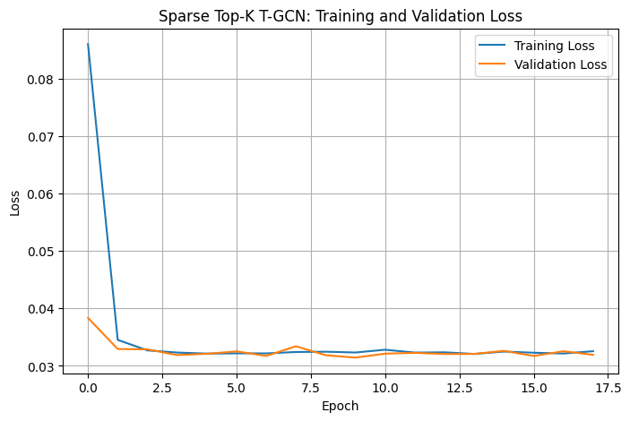

```python
# Plot training and validation loss

plt.figure(figsize=(8, 5))

plt.plot(train_history, label="Training Loss")
plt.plot(val_history, label="Validation Loss")

plt.title("Sparse Top-K T-GCN: Training and Validation Loss")
plt.xlabel("Epoch")
plt.ylabel("Loss")

plt.legend()
plt.grid(True)

plt.show()
```

```python
# Evaluate Sparse Top-K T-GCN on test set

model.load_state_dict(torch.load("tgcn_sparse_best.pth"))
model.eval()

all_preds = []
all_trues = []

with torch.no_grad():
    for batch in test_loader:
        batch_x = batch.x_seq.to(device)

        batch_preds_scaled = model(
            batch_x,
            edge_index,
            edge_weight
        ).cpu().numpy()

        batch_trues_scaled = batch.y.view(-1, num_nodes).cpu().numpy()

        all_preds.append(batch_preds_scaled)
        all_trues.append(batch_trues_scaled)

preds_scaled = np.vstack(all_preds)
trues_scaled = np.vstack(all_trues)

preds = scaler_y.inverse_transform(preds_scaled)
trues = scaler_y.inverse_transform(trues_scaled)

mae = mean_absolute_error(trues, preds)
rmse = np.sqrt(mean_squared_error(trues, preds))

print("Sparse Top-K T-GCN Test MAE:", mae)
print("Sparse Top-K T-GCN Test RMSE:", rmse)
print("Predictions shape:", preds.shape)
print("Actual values shape:", trues.shape)
```

```
Sparse Top-K T-GCN Test MAE: 4.589795112609863
Sparse Top-K T-GCN Test RMSE: 6.4220199382975
Predictions shape: (36, 10)
Actual values shape: (36, 10)
```

```python
# Zone-wise evaluation

sparse_zone_results = []

for i in range(num_nodes):
    zone_mae = mean_absolute_error(trues[:, i], preds[:, i])
    zone_rmse = np.sqrt(mean_squared_error(trues[:, i], preds[:, i]))

    sparse_zone_results.append([
        i,
        zone_mae,
        zone_rmse
    ])

sparse_zone_results_df = pd.DataFrame(
    sparse_zone_results,
    columns=["zone", "MAE", "RMSE"]
)

sparse_zone_results_df
```

|  | zone | MAE | RMSE |
| --- | --- | --- | --- |
| 0 | 0 | 5.972229 | 8.215327 |
| 1 | 1 | 3.721955 | 4.916345 |
| 2 | 2 | 4.131580 | 5.694741 |
| 3 | 3 | 5.595373 | 8.027655 |
| 4 | 4 | 3.878453 | 5.224329 |
| 5 | 5 | 5.660752 | 7.792942 |
| 6 | 6 | 5.141541 | 7.334659 |
| 7 | 7 | 4.250249 | 5.524728 |
| 8 | 8 | 4.018728 | 5.547928 |
| 9 | 9 | 3.527093 | 4.556877 |

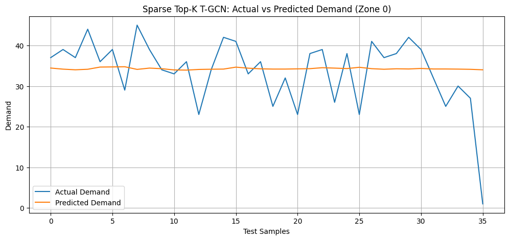

```python
# Actual vs Predicted Demand

zone_id = 0

plt.figure(figsize=(12, 5))

plt.plot(
    trues[:, zone_id],
    label="Actual Demand"
)

plt.plot(
    preds[:, zone_id],
    label="Predicted Demand"
)

plt.title("Sparse Top-K T-GCN: Actual vs Predicted Demand (Zone 0)")
plt.xlabel("Test Samples")
plt.ylabel("Demand")

plt.legend()
plt.grid(True)

plt.show()
```

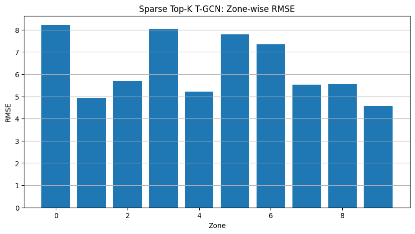

```python
# Zone-wise RMSE visualisation

plt.figure(figsize=(10, 5))

plt.bar(
    sparse_zone_results_df["zone"],
    sparse_zone_results_df["RMSE"]
)

plt.title("Sparse Top-K T-GCN: Zone-wise RMSE")
plt.xlabel("Zone")
plt.ylabel("RMSE")

plt.grid(axis="y")

plt.show()
```

```python
# Save results

np.save("tgcn_sparse_test_preds.npy", preds)
np.save("tgcn_sparse_test_trues.npy", trues)

sparse_zone_results_df.to_csv(
    "tgcn_sparse_zonewise_results.csv",
    index=False
)

pd.DataFrame({
    "Metric": ["MAE", "RMSE"],
    "Value": [mae, rmse]
}).to_csv(
    "tgcn_sparse_overall_results.csv",
    index=False
)
```

### Sparse Top-K T-GCN Results and Interpretation

This indicates that correcting the training pipeline, improving reproducibility, and refining graph handling helped stabilise model performance. However, the model still underperformed compared to the original LSTM and baseline T-GCN models.

The results suggest that while sparse graph structures can reduce noise, they may also remove important spatial relationships between zones. This further highlights that graph construction plays a critical role in T-GCN performance and must balance sparsity with meaningful connectivity.

## Improvement Experiment: Feature-Enhanced Sparse Top-K T-GCN

To improve the Sparse Top-K T-GCN model, additional temporal and statistical features are added to the input data. Instead of using only raw demand values, this experiment includes lag demand, rolling mean demand, cyclical time features, and weekend indicators.

The aim is to provide the model with more context about demand patterns across time while still using the sparse top-k graph structure.

### Feature Engineering

```python
# Feature-enhanced dataset for Sparse Top-K T-GCN

pivot = pivot_demand.copy()
pivot = pivot.sort_index()

# Demand values
demand = pivot.values.astype(np.float32)

# Time-based features
hours = pivot.index.hour.to_numpy()
days = pivot.index.dayofweek.to_numpy()

hour_sin = np.sin(2 * np.pi * hours / 24)
hour_cos = np.cos(2 * np.pi * hours / 24)

day_sin = np.sin(2 * np.pi * days / 7)
day_cos = np.cos(2 * np.pi * days / 7)

weekend = (days >= 5).astype(float)

num_timesteps, num_nodes = demand.shape

# Repeat time features for every zone
hour_sin = np.repeat(hour_sin.reshape(-1, 1), num_nodes, axis=1)
hour_cos = np.repeat(hour_cos.reshape(-1, 1), num_nodes, axis=1)

day_sin = np.repeat(day_sin.reshape(-1, 1), num_nodes, axis=1)
day_cos = np.repeat(day_cos.reshape(-1, 1), num_nodes, axis=1)

weekend = np.repeat(weekend.reshape(-1, 1), num_nodes, axis=1)

# Lag demand feature
lag_1 = np.roll(demand, shift=1, axis=0)
lag_1[0, :] = demand[0, :]

# Rolling mean feature
rolling_mean = (
    pivot
    .rolling(window=3, min_periods=1)
    .mean()
    .values
    .astype(np.float32)
)

# Stack all features
feature_data = np.stack(
    [
        demand,
        lag_1,
        rolling_mean,
        hour_sin,
        hour_cos,
        day_sin,
        day_cos,
        weekend
    ],
    axis=-1
)

print("Feature data shape:", feature_data.shape)
```

```
Feature data shape: (361, 10, 8)
```

### Create Feature-Based Sequences

```python
def create_feature_sequences(feature_data, target_data, seq_len=6):

    X_feat, y_feat = [], []

    for i in range(len(feature_data) - seq_len):

        X_feat.append(feature_data[i:i+seq_len])
        y_feat.append(target_data[i+seq_len])

    return np.array(X_feat), np.array(y_feat)


seq_len = 6

X_feat, y_feat = create_feature_sequences(
    feature_data,
    demand,
    seq_len
)

print("X_feat shape:", X_feat.shape)
print("y_feat shape:", y_feat.shape)
```

```
X_feat shape: (355, 6, 10, 8)
y_feat shape: (355, 10)
```

### Train, Validation and Test Split

```python
num_samples = X_feat.shape[0]

split_idx = int(num_samples * 0.8)
val_idx = int(split_idx + (num_samples - split_idx) * 0.5)

X_train = X_feat[:split_idx]
y_train = y_feat[:split_idx]

X_val = X_feat[split_idx:val_idx]
y_val = y_feat[split_idx:val_idx]

X_test = X_feat[val_idx:]
y_test = y_feat[val_idx:]

print("Feature dataset splits:")
print("Train:", X_train.shape)
print("Validation:", X_val.shape)
print("Test:", X_test.shape)
```

```
Feature dataset splits:
Train: (284, 6, 10, 8)
Validation: (35, 6, 10, 8)
Test: (36, 6, 10, 8)
```

### Scale Features and Target Values

```python
from sklearn.preprocessing import MinMaxScaler

# Scale target values
scaler_y = MinMaxScaler()

y_train_scaled = scaler_y.fit_transform(y_train)
y_val_scaled = scaler_y.transform(y_val)
y_test_scaled = scaler_y.transform(y_test)

# Scale input features
num_features = X_train.shape[-1]

scaler_x = MinMaxScaler()

X_train_2d = X_train.reshape(-1, num_features)
X_val_2d = X_val.reshape(-1, num_features)
X_test_2d = X_test.reshape(-1, num_features)

X_train_scaled = scaler_x.fit_transform(X_train_2d).reshape(X_train.shape)
X_val_scaled = scaler_x.transform(X_val_2d).reshape(X_val.shape)
X_test_scaled = scaler_x.transform(X_test_2d).reshape(X_test.shape)

print("Scaled training input shape:", X_train_scaled.shape)
```

```
Scaled training input shape: (284, 6, 10, 8)
```

### Create Feature-Enhanced DataLoaders

```python
def make_feature_dataset(X_arr, y_arr_scaled):

    dataset = []

    for i in range(X_arr.shape[0]):

        x_seq = torch.tensor(
            X_arr[i],
            dtype=torch.float32
        )

        y_target = torch.tensor(
            y_arr_scaled[i],
            dtype=torch.float32
        )

        data = Data()
        data.x_seq = x_seq
        data.y = y_target

        dataset.append(data)

    return dataset


train_dataset = make_feature_dataset(X_train_scaled, y_train_scaled)
val_dataset = make_feature_dataset(X_val_scaled, y_val_scaled)
test_dataset = make_feature_dataset(X_test_scaled, y_test_scaled)

batch_size = 16

train_loader = DataLoader(
    train_dataset,
    batch_size=batch_size,
    shuffle=True
)

val_loader = DataLoader(
    val_dataset,
    batch_size=batch_size,
    shuffle=False
)

test_loader = DataLoader(
    test_dataset,
    batch_size=batch_size,
    shuffle=False
)
```

### Train Feature-Enhanced Sparse Top-K T-GCN

```python
# Model Initialisation

in_feats = X_train_scaled.shape[-1]

model = TGCN_Model(
    num_nodes=num_nodes,
    seq_len=seq_len,
    in_feats=in_feats,
    gcn_out=16,
    gru_hidden=64
).to(device)

optimizer = torch.optim.Adam(
    model.parameters(),
    lr=1e-3
)

criterion = nn.MSELoss()

n_epochs = 60
best_val_loss = np.inf
patience = 8
wait = 0

print("Using input features:", in_feats)
```

```
Using input features: 8
```

```python
# Model Training

feature_train_history = []
feature_val_history = []

for epoch in range(n_epochs):

    model.train()
    train_losses = []

    for batch in train_loader:
        batch_x = batch.x_seq.to(device)
        batch_y = batch.y.view(-1, num_nodes).to(device)

        optimizer.zero_grad()

        preds_train = model(batch_x, edge_index, edge_weight)
        loss = criterion(preds_train, batch_y)

        loss.backward()
        optimizer.step()

        train_losses.append(loss.item())

    avg_train = np.mean(train_losses)

    model.eval()
    val_losses = []

    with torch.no_grad():
        for batch in val_loader:
            batch_x = batch.x_seq.to(device)
            batch_y = batch.y.view(-1, num_nodes).to(device)

            preds_val = model(batch_x, edge_index, edge_weight)
            loss = criterion(preds_val, batch_y)

            val_losses.append(loss.item())

    avg_val = np.mean(val_losses)

    feature_train_history.append(avg_train)
    feature_val_history.append(avg_val)

    print(
        f"Epoch {epoch+1} - "
        f"train_loss: {avg_train:.6f} - "
        f"val_loss: {avg_val:.6f}"
    )

    if avg_val < best_val_loss:
        best_val_loss = avg_val
        torch.save(model.state_dict(), "tgcn_feature_sparse_best.pth")
        wait = 0
    else:
        wait += 1

        if wait >= patience:
            print("Early stopping.")
            break
```

```
Epoch 1 - train_loss: 0.097465 - val_loss: 0.039279
Epoch 2 - train_loss: 0.040343 - val_loss: 0.041165
Epoch 3 - train_loss: 0.034714 - val_loss: 0.036483
Epoch 4 - train_loss: 0.033594 - val_loss: 0.035710
Epoch 5 - train_loss: 0.033198 - val_loss: 0.034856
Epoch 6 - train_loss: 0.032981 - val_loss: 0.033602
Epoch 7 - train_loss: 0.032672 - val_loss: 0.033723
Epoch 8 - train_loss: 0.032137 - val_loss: 0.033164
Epoch 9 - train_loss: 0.032004 - val_loss: 0.033015
Epoch 10 - train_loss: 0.031906 - val_loss: 0.033586
Epoch 11 - train_loss: 0.031863 - val_loss: 0.032816
Epoch 12 - train_loss: 0.031725 - val_loss: 0.032782
Epoch 13 - train_loss: 0.031772 - val_loss: 0.032064
Epoch 14 - train_loss: 0.031676 - val_loss: 0.032940
Epoch 15 - train_loss: 0.031820 - val_loss: 0.033050
Epoch 16 - train_loss: 0.031935 - val_loss: 0.033082
Epoch 17 - train_loss: 0.031590 - val_loss: 0.033089
Epoch 18 - train_loss: 0.031373 - val_loss: 0.033010
Epoch 19 - train_loss: 0.031481 - val_loss: 0.032848
Epoch 20 - train_loss: 0.031364 - val_loss: 0.032844
Epoch 21 - train_loss: 0.031473 - val_loss: 0.033110
Early stopping.
```

### Training Loss Visualisation

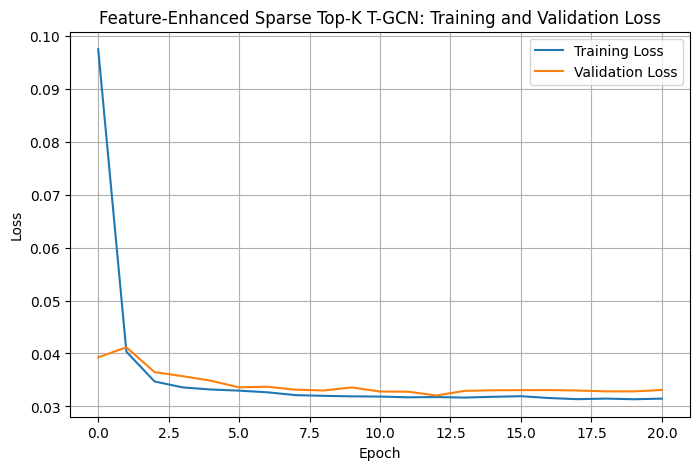

```python
plt.figure(figsize=(8, 5))

plt.plot(feature_train_history, label="Training Loss")
plt.plot(feature_val_history, label="Validation Loss")

plt.title("Feature-Enhanced Sparse Top-K T-GCN: Training and Validation Loss")
plt.xlabel("Epoch")
plt.ylabel("Loss")

plt.legend()
plt.grid(True)

plt.show()
```

### Evaluate Feature-Enhanced Sparse Top-K T-GCN

```python
model.load_state_dict(torch.load("tgcn_feature_sparse_best.pth"))
model.eval()

all_preds = []
all_trues = []

with torch.no_grad():
    for batch in test_loader:
        batch_x = batch.x_seq.to(device)

        batch_preds_scaled = model(
            batch_x,
            edge_index,
            edge_weight
        ).cpu().numpy()

        batch_trues_scaled = batch.y.view(-1, num_nodes).cpu().numpy()

        all_preds.append(batch_preds_scaled)
        all_trues.append(batch_trues_scaled)

preds_scaled = np.vstack(all_preds)
trues_scaled = np.vstack(all_trues)

preds = scaler_y.inverse_transform(preds_scaled)
trues = scaler_y.inverse_transform(trues_scaled)

feature_sparse_mae = mean_absolute_error(trues, preds)
feature_sparse_rmse = np.sqrt(mean_squared_error(trues, preds))

print("Feature-Enhanced Sparse Top-K T-GCN Test MAE:", feature_sparse_mae)
print("Feature-Enhanced Sparse Top-K T-GCN Test RMSE:", feature_sparse_rmse)
print("Predictions shape:", preds.shape)
print("Actual values shape:", trues.shape)
```

```
Feature-Enhanced Sparse Top-K T-GCN Test MAE: 4.7156171798706055
Feature-Enhanced Sparse Top-K T-GCN Test RMSE: 6.489712129624135
Predictions shape: (36, 10)
Actual values shape: (36, 10)
```

### Zone-Wise Results

```python
feature_sparse_zone_results = []

for i in range(num_nodes):

    zone_mae = mean_absolute_error(trues[:, i], preds[:, i])
    zone_rmse = np.sqrt(mean_squared_error(trues[:, i], preds[:, i]))

    feature_sparse_zone_results.append([
        i,
        zone_mae,
        zone_rmse
    ])

feature_sparse_zone_results_df = pd.DataFrame(
    feature_sparse_zone_results,
    columns=["zone", "MAE", "RMSE"]
)

feature_sparse_zone_results_df
```

|  | zone | MAE | RMSE |
| --- | --- | --- | --- |
| 0 | 0 | 6.191004 | 8.289910 |
| 1 | 1 | 4.077461 | 5.209010 |
| 2 | 2 | 4.362269 | 5.905903 |
| 3 | 3 | 5.636501 | 7.958071 |
| 4 | 4 | 3.951510 | 5.392215 |
| 5 | 5 | 5.634031 | 7.767151 |
| 6 | 6 | 5.265170 | 7.378565 |
| 7 | 7 | 4.488897 | 5.596849 |
| 8 | 8 | 3.942288 | 5.460375 |
| 9 | 9 | 3.607043 | 4.701956 |

### Actual vs Predicted Demand

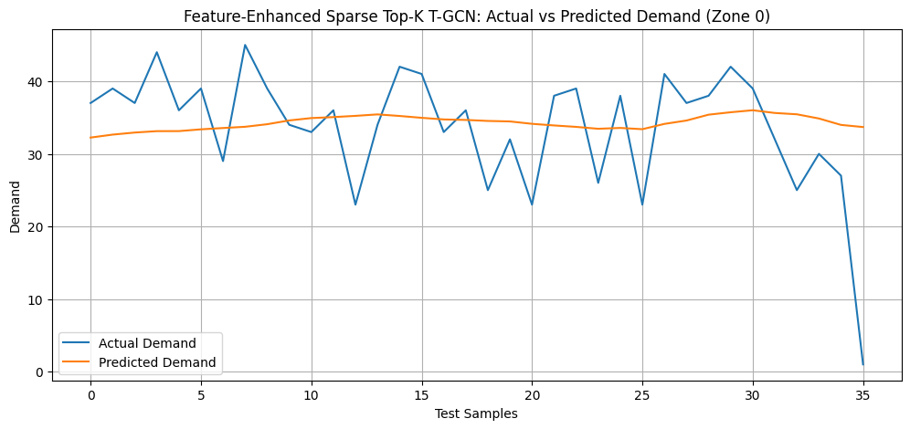

```python
zone_id = 0

plt.figure(figsize=(12, 5))

plt.plot(
    trues[:, zone_id],
    label="Actual Demand"
)

plt.plot(
    preds[:, zone_id],
    label="Predicted Demand"
)

plt.title("Feature-Enhanced Sparse Top-K T-GCN: Actual vs Predicted Demand (Zone 0)")
plt.xlabel("Test Samples")
plt.ylabel("Demand")

plt.legend()
plt.grid(True)

plt.show()
```

### Zone-Wise RMSE Visualisation

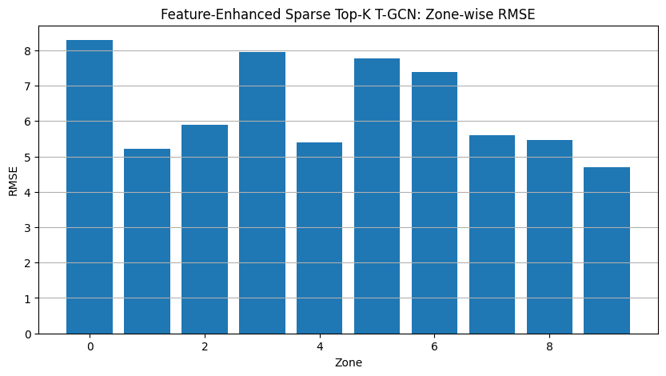

```python
plt.figure(figsize=(10, 5))

plt.bar(
    feature_sparse_zone_results_df["zone"],
    feature_sparse_zone_results_df["RMSE"]
)

plt.title("Feature-Enhanced Sparse Top-K T-GCN: Zone-wise RMSE")
plt.xlabel("Zone")
plt.ylabel("RMSE")

plt.grid(axis="y")

plt.show()
```

### Results Interpretation

The zone-wise RMSE analysis also shows performance differences across delivery zones. Some zones achieved lower prediction error, while zones such as Zone 0 and Zone 3 recorded higher RMSE values, suggesting that demand patterns vary in complexity across locations.

Overall, the experiment demonstrates that combining sparse graph structures with feature-enhanced inputs can produce stable spatial-temporal forecasting performance, although further improvements in graph construction and model architecture may still be required for stronger predictive accuracy.